# DataChallenge

### Q4: Clustering:How can we group observations in MyData1 based on the number of years living in the Township (Q3)?

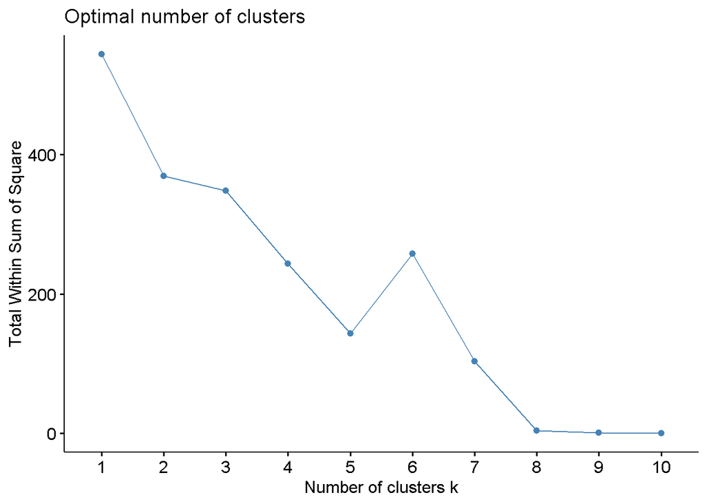

```r
library(cluster)
library(factoextra)
data_cluster <- MyData1[,c("Q3_0 - 4 Years", "Q3_5 - 9 Years", "Q3_10 - 19 Years", "Q3_20 - 39 Years", "Q3_Over 40 Years", "Q3_I do not live in the Township")]
fviz_nbclust(data_cluster , kmeans, method = "wss")
```

```r
model_clustering <- kmeans(data_cluster, centers = 7)
summary(model_clustering)
```

```
##              Length Class  Mode
## cluster      686    -none- numeric
## centers       42    -none- numeric
## totss          1    -none- numeric
## withinss       7    -none- numeric
## tot.withinss   1    -none- numeric
## betweenss      1    -none- numeric
## size           7    -none- numeric
## iter           1    -none- numeric
## ifault         1    -none- numeric
```

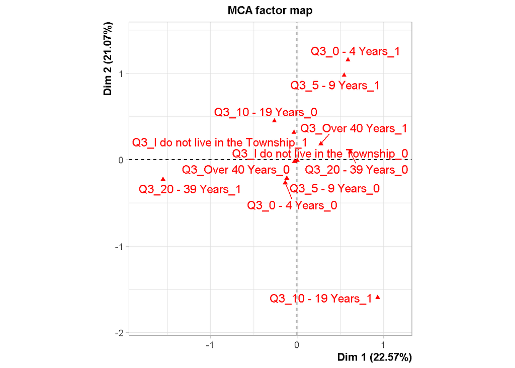

[figure not shown]

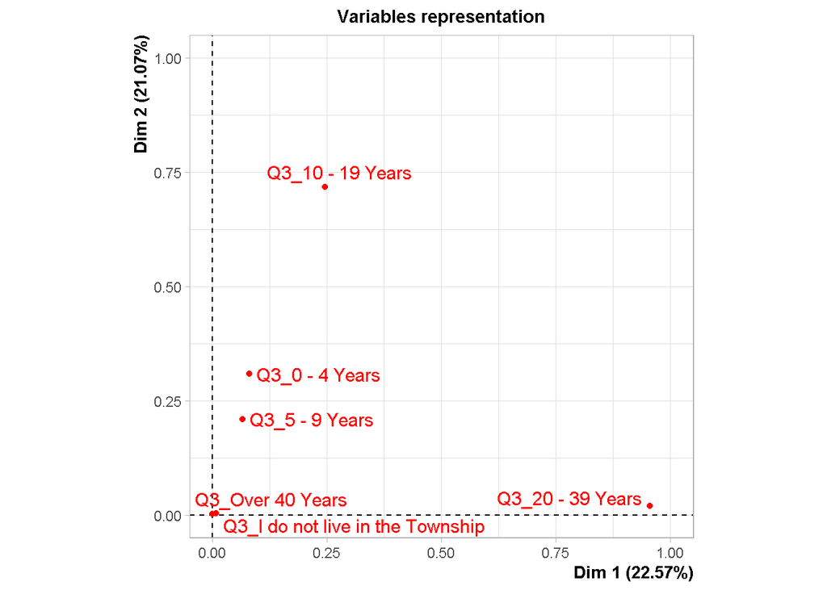

```r
library(FactoMineR)
data_mca <- MCA(data_cluster)
```

```r
cluster_assignments <- as.factor(model_clustering$cluster)
```

## Conclusion

We might speculate that the town’s demographic makeup or geographic location could be contributing to the observed patterns in the data. Further analysis of the township’s characteristics, such as population size, employment opportunities, and recreational facilities, may help explain the observed differences between the age groups.